# End-to-End COVID-19 Analysis Tutorial

*An Application Oriented Data Science Pipeline Tutorial*

Creator: [Hrithik Bansal](https://hrithikbansal.com)

# Introduction

In order to teach the basics of Data Science, this tutorial uses an underlying project to guide the reader through an end-to-end datascience pipeline, implemented from scratch. This tutorial is specifically made to teach the reader about certain data science concepts. These include finding a dataset, cleaning it up, doing preliminary statisitical analysis on it, and then diving deep into specific analysis techniques (for example: classification, prediction). Finally, the learnings as part of the tutorial will then be communicated to the reader as the findings of the process.

The tutorial is specifically meant for an audience with limited prior knowledge about Data Science. However, all are encouraged to read through it! In case you see any errors with this tutorial, either logical or semantic, please dont hesitate to reach out, your feedback can be used to improve this further.

## Motivation

Current world scenario has been set up in a way where there is an abundace of real world data. Almost each industry has some sort of integeration to collect data, as this is something that organizations, or even individuals, can use to better understand a particular phononmenon, and use their findings as a way to *communicate* aspects of data which are not apparent through hollistic analysis.

In addition, having some knowledge of how an end-to-end Data Science 'pipeline' actually goes a long way in the professional industry, with one being able to create a 'toolbox' that can be used to understand data from a quantative, as well as a qualitative perspective.

## Libraries Used

We'll start off by importing some additional libraries, which offer great features for working with, and analysing data. Additional libraries will be included as required, throughout the tutorial.

*Note:* In a real world enviroment, it is preferred that all the required imports be done at the top level in order to maintain versions and improve readability.

```python
# For Data Analysis and Manipulation
import pandas as pd
# For Scientific Computing (+ Data Respresenation, Operations)
import numpy as np
# For Visualizations
import matplotlib.pyplot as plt
```

# Working with the Data

In order to better communicate how available tools for data analysis can be used in order to explore and manipulate data, this tutorial uses COVID-19 analysis as a central theme to establish a application. The goal of this tutorial is to not 'prove' something about the data, or validate a fact from a social media post regarding the virus. However, it is to do some analysis on the data, and then **communicate** the findings throughout.

This will also include what the course of action is for a typical data analysis project, with a thorough explanation of techniques used, and the idea behind their selection.

## About the Data

In order to examine COVID-19, data is required. Finding data can sometimes be difficult, due to both, under and over availablity. For example, if someone wants to look at stock data, they may have trouble gaining access to readily available data which is recent. They would however be able to find an excess amount of historical stock data, in nice 'csv' formats. Such ambiguity can make the data selection process somewhat tricky. However, in these cases, it is important to recognize a central theme, and use that as a starting point. As for actually finding the data, **see the Finding Data section in Resources**.

For this tutorial, keeping in with the COVID-19 central theme, I decided to go with the New York Times COVID-19 data -> [NY Times COVID-19 Dataset](https://github.com/nytimes/covid-19-data). Currently, there are several different 'forms' and 'flavors' of COVID-19 data available all over the internet. However, I chose this dataset specicifically for two reasons -

1. The NY Times GitHub repository is set up in a way that supports live data. What this essentially means is that the data or csv files get automatically updated with new data over time. This allows us, or data scientists, access to the latest data, without too much effort of API integereation, or fetching the data ourselves.
2. The repository contains many different datasets for the US, include state, county data. In addition, data regarding face mask use, as well as college level cases has also been given. This, incombination with a phenomenally documented repository contianing a data dictionary, make things during the analysis phase of the data, much more hassle free.

We will also be looking at Historical Bitcoin data, limited to the scope of data for COVID-19, and see if there are certain correlations between both. The Bitcoin/USD data was obtained [here](https://www.cryptodatadownload.com/data/gemini/)

## Loading Data

As with any other analysis, it is important to first load the data into the enviroment, in order to further analyse it.

```python
# For indepth information about each dataset, refer to the link above

# Path to Data for COVID in US - Statewise
us_states_data = './data/us-states.csv'

# Path to Data for Mask Use in the US by County
mask_data = './data/mask-use-by-county.csv'

bitcoin = './data/gemini_BTCUSD_day.csv'

# Fips Map Data, will be useful later to correlate FIPS with County Name
# The data was obtained here -
# https://github.com/kjhealy/fips-codes/blob/master/state_and_county_fips_master.csv
# Read more about FIPS here -
# https://transition.fcc.gov/oet/info/maps/census/fips/fips.txt
fips = './data/fips_map.csv'

# Reading in the data as a Pandas dataframe for easy manipulation
us_states = pd.read_csv(us_states_data)
mask = pd.read_csv(mask_data)

btc = pd.read_csv(bitcoin)

fips = pd.read_csv(fips)

# Viewing first few rows to see how the data looks like
```

```python
print(us_states.describe())
us_states.head(5)
```

```
               fips         cases        deaths
count  24104.000000  2.410400e+04  24104.000000
mean      31.944366  2.302986e+05   4721.387612
std       18.657928  4.335252e+05   8317.182781
min        1.000000  1.000000e+00      0.000000
25%       17.000000  9.034250e+03    206.000000
50%       31.000000  6.996200e+04   1461.000000
75%       46.000000  2.758982e+05   5533.500000
max       78.000000  3.766679e+06  62625.000000
```

|  | date | state | fips | cases | deaths |
| --- | --- | --- | --- | --- | --- |
| 0 | 2020-01-21 | Washington | 53 | 1 | 0 |
| 1 | 2020-01-22 | Washington | 53 | 1 | 0 |
| 2 | 2020-01-23 | Washington | 53 | 1 | 0 |
| 3 | 2020-01-24 | Illinois | 17 | 1 | 0 |
| 4 | 2020-01-24 | Washington | 53 | 1 | 0 |

```python
mask.head(5)
```

|  | COUNTYFP | NEVER | RARELY | SOMETIMES | FREQUENTLY | ALWAYS |
| --- | --- | --- | --- | --- | --- | --- |
| 0 | 1001 | 0.053 | 0.074 | 0.134 | 0.295 | 0.444 |
| 1 | 1003 | 0.083 | 0.059 | 0.098 | 0.323 | 0.436 |
| 2 | 1005 | 0.067 | 0.121 | 0.120 | 0.201 | 0.491 |
| 3 | 1007 | 0.020 | 0.034 | 0.096 | 0.278 | 0.572 |
| 4 | 1009 | 0.053 | 0.114 | 0.180 | 0.194 | 0.459 |

```python
btc.head(5)
```

|  | Unix Timestamp | Date | Symbol | Open | High | Low | Close | Volume |
| --- | --- | --- | --- | --- | --- | --- | --- | --- |
| 0 | 1620964800000 | 2021-05-14 04:00:00 | BTCUSD | 49221.07 | 51575.16 | 48894.79 | 50051.71 | 1673.430728 |
| 1 | 1620878400000 | 2021-05-13 04:00:00 | BTCUSD | 50493.11 | 51389.95 | 46962.39 | 49221.07 | 4250.468629 |
| 2 | 1620792000000 | 2021-05-12 04:00:00 | BTCUSD | 57820.00 | 57998.26 | 45000.00 | 50493.11 | 6438.293435 |
| 3 | 1620705600000 | 2021-05-11 04:00:00 | BTCUSD | 55194.75 | 57898.00 | 54684.00 | 57820.00 | 1432.556473 |
| 4 | 1620619200000 | 2021-05-10 04:00:00 | BTCUSD | 59407.78 | 59584.99 | 53434.31 | 55194.75 | 2583.418054 |

We now have the data into dataframes, which is essentially a data structure given by pandas, used to represent 2Dimensional data in Tabular Form. Pandas also comes with a variety of supporting functions that help make searching, indexing and analysis of data much more intuitive.

In order tp proceed further, we must fix any data formatting issues, as well as tidy things up for a smoother future analysis.

## Tidying Data

In order to better analyse the data, it is important to make it consistent. This includes checking and dealing with missing values, converting and casting to proper types, and re-arranging the columns/values. While we may not do everything in this tutorial, each dataset has its own requirements for tidying it up, and hence depends on the final application.

Since the datasets we have, been generated by a bot, missing data is not a major problem here, and if encountered, will be dealt in the process. We do however, need to do some re-arrangment, as well as other minor changes.

```python
# Lets convert the date columns in our dataset to DateTime objects, which
# makes time series analysis far more convenient.
us_states['date'] = pd.to_datetime(us_states['date'])
# This is a hacky fix to remove the timestamp from the given date
# Makes things more consistent with our COVID data
btc['Date'] = btc['Date'].apply(lambda x: x.split(' ')[0])
btc['Date'] = pd.to_datetime(btc['Date'])

# Renaming mask data columns to lowercase, and make things consistent
mask.rename(columns={
    'COUNTYFP':'fp',
    'NEVER':'never',
    'RARELY':'rarely',
    'SOMETIMES':'sometimes',
    'FREQUENTLY':'frequently',
    'ALWAYS':'always'
    }, inplace=True)

btc.rename(columns={
    'Date':'date',
    'Symbol':'symbol',
    'Open':'open',
    'High':'high',
    'Low':'low',
    'Close':'close',
    'Volume':'volume'
    }, inplace=True)

# The bitcoin day trade data has additional information, which is not
# required. Also, since we're only looking at this from COVID-19 perspective,
# data older than 2020, specifically 2020-01-21, will be dropped
btc.drop('Unix Timestamp', axis=1, inplace=True)
btc = btc.loc[btc['date'] >= '2020-01-21']
# Sort and reorder our data to match with COVID data
btc.sort_values('date', ignore_index=True, inplace=True)

# We will be looking at county wise distribution of cases for mask use.
# Since the current data represents Mask Data using COUNTYFP, we will use
# the fips map data to map the unique code to the county name.

# Create a new column to store county information
mask['county'] = ''

# Iterate over each fp in mask, and set corresponding county name in the
# new column
for index, row in mask.iterrows():
    # countyFP that needs to be searched
    countyFP = row['fp']

    # Searching for the row containing the same
    # try - except will handle any cases where the county fp is not found
    # thereby eliminating errors when running
    try:
        county = fips.loc[fips['fips'] == countyFP]
        # Since loc returns the corresponding row, lets take out only the
        # required county name
        county = county['name'].item()
        # Removing the 'County' suffix from the mapped name
        # Since the format is known, we can 'break' the string at the first
        # space char, and get only the name, which is the first part of it,
        # using indexing
        county = county.split(' ')[0]
    except:
        # Assign empty string since county name not found
        county = ''

    # Set the corresponding value in county column
    mask.at[index, 'county'] = county
```

# Extracting Information from Data

## Exploratory Data Analysis and Visualization

Preliminary statistics, normalization, centering data and correlations

Graph all the state data collectively, to get idea of state vs cases

Select three - 4 states

### Collective State Analysis for COVID-19 Cases, Deaths and Recovery

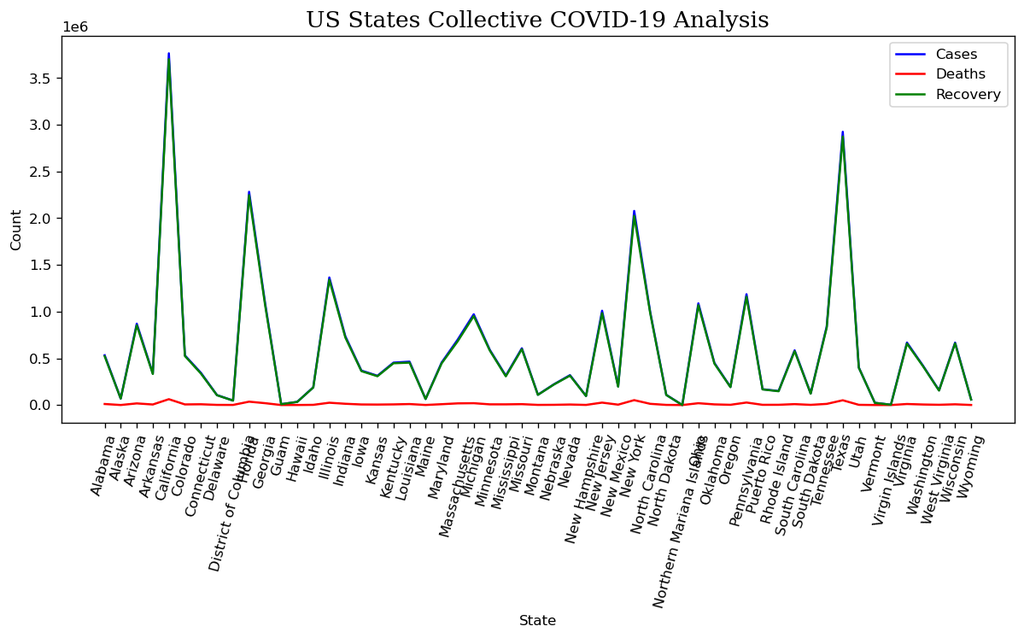

```python
# Lets graph the States data collective, to get an idea of case
# distribution

# Since the us_states data is cumulative, we will take only the latest
# values for our collective analysis

# Note: We create a copy here to leave the original data unchanged, as
# dataframes are referenced by default. Read more on Pandas documentation,
# listed in resources
state_all_time = us_states.loc[us_states['date']==pd.to_datetime('2021-05-13')].copy()

# Adding a column for recovery
state_all_time['recovery'] = state_all_time['cases']-state_all_time['deaths']

# Lets graph this to make this more visually appealing
# Refer to matplot lib documentation, linked in resources to understand
# what each function does
plt.figure(figsize=(12, 5), dpi=120)
plt.plot(state_all_time['state'], state_all_time['cases'], c='b', label='Cases')
plt.plot(state_all_time['state'], state_all_time['deaths'], c='r', label='Deaths')
plt.plot(state_all_time['state'], state_all_time['recovery'], c='g', label='Recovery')
plt.xticks(rotation=75, fontsize=10)
plt.title('US States Collective COVID-19 Analysis',
          fontdict={'fontname':'serif', 'fontsize':16})
# Add labels to increase readability
plt.xlabel('State')
plt.ylabel('Count')
plt.legend()
# Show the plot
plt.show()
```

### Interactive COVID-19 'Dashboard' Map

To make things slightly interesting, lets make a visual map using Folium, to interactively look at COVID-19 information for a given state.

```python
# Folium offers a great wrapper to Python for creating real-world
# geo-visualizations
import folium

# Creating a map using Folium, centered at U.S. (contigous states)
# The exact value was obtained using a Google Search
state_map_viz = folium.Map(location=[37.09, -95.71], zoom_start=3.5)

# In order to map each state using Folium, we require the state latitude
# and longitude co-ordinates. Since there is no such support through a
# library, we will be using a mapping approach, and utilize a premade
# dataset to get the co-ordinate values

# Since a ready dataset did not exist, I created one using information
# provided here -
# https://developers.google.com/public-data/docs/canonical/states_csv

# Importing the data as a DataFrame
states_map = './data/states.csv'
mappings = pd.read_csv(states_map)

# Since the mappings are limited to US States given by the mappings
# dataset, there are certain non-contigous states which may be left out
# of the visualization as a result

# # For each state, lets make a marker
for index, r in mappings.iterrows():
    # Get the corresponding state data
    data = state_all_time.loc[state_all_time['state']==r['name']]
    # Now we have the 'row', lets extract the relevant data and create a
    # 'popup'
    cases = data['cases'].item()
    deaths = data['deaths'].item()
    recovery = data['recovery'].item()
    popup = '{}\n\nTotal Cases: {}\nTotal Deaths: {}\nTotal Recovery: {}'.format(r['name'], cases, deaths, recovery)
    # Create and add the pindrop markers
    tooltip = 'View {} COVID-19 Data'.format(r['name'])
    icon = folium.Icon(color='white', icon_color='green')
    folium.Marker(
        [float(r['latitude']), float(r['longitude'])],
        popup=popup,
        tooltip=tooltip,
        icon=icon).add_to(state_map_viz)

print('\t\tHover Over Marker to View State Information')
display(state_map_viz)
```

```
		Hover Over Marker to View State Information
```

Make this Notebook Trusted to load map: File -> Trust Notebook

[interactive chart not shown]

To dive deeper into this, let us selectively look at **California, New York and Maryland.**

### Time Series Analysis and Bitcoin Correlation

Since we have access to time series data, lets see how the number of cases changed for the three states over time

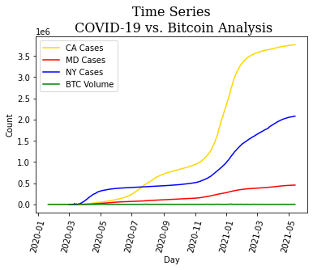

```python
# Lets get individual state data

# groupby will group all rows according to each unique 'state' value
# A dictionary is generated to map each state dataframe to its name as
# a key. This will be useful later on.
groups = us_states.groupby('state')
states = {}
for state, dataframe in groups:
    states[state] = dataframe.copy()

# California data
ca = states['California'].copy()
ca.sort_values(by='date', ignore_index=True, inplace=True)
# New York data
ny = states['New York'].copy()
ny.sort_values(by='date', ignore_index=True, inplace=True)
# Maryland data
md = states['Maryland'].copy()
md.sort_values(by='date', ignore_index=True, inplace=True)

# Lets plot the data as is, and see if it makes sense
# plt.figure(figsize=(12, 5))
plt.plot(ca['date'], ca['cases'], c='gold', label='CA Cases')
plt.plot(md['date'], md['cases'], c='r', label='MD Cases')
plt.plot(ny['date'], ny['cases'], c='b', label='NY Cases')
plt.plot(btc['date'], btc['volume'], c='g', label='BTC Volume')
plt.xticks(rotation=75, fontsize=10)
plt.title('Time Series\n COVID-19 vs. Bitcoin Analysis',
          fontdict={'fontname':'serif', 'fontsize':16})
# Add labels to increase readability
plt.xlabel('Day')
plt.ylabel('Count')
plt.legend()
# Show the plot
plt.show()
```

As we can see from the above plot, visually there does not seem to be any relation between the COVID-19 cases and Bitcoin volume traded. Even visually, the volume of bitcoint does not compare in magnitude to the number of cases. Hence, a different approach is required here.

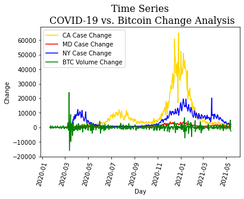

```python
# Since the given state data is cumulative, we will create an new
# column in the dataframe to store the change in cases overtime
def calcChange(df, cname, change_name='change'):
    # Iterate over dataframe rows
    df['change'] = 0
    for i, r in df.iterrows():
        # Ignore the first row
        if i != 0:
            df.at[i, change_name] = r[cname] - df.at[i-1, cname]
    return

# Computing and storing the change for each dataframe
calcChange(ca, 'cases')
calcChange(ny, 'cases')
calcChange(md, 'cases')
calcChange(btc, 'volume')

# Now that we have a measure of change overtime, it is easier to compare
# the state COVID-19 data with the Bitcoin data

# Lets plot the data change, and see if it makes more sense
# plt.figure(figsize=(12, 5))
plt.plot(ca['date'], ca['change'], c='gold', label='CA Case Change')
plt.plot(md['date'], md['change'], c='r', label='MD Case Change')
plt.plot(ny['date'], ny['change'], c='b', label='NY Case Change')
plt.plot(btc['date'], btc['change'], c='g', label='BTC Volume Change')
plt.xticks(rotation=75, fontsize=10)
plt.title('Time Series\n COVID-19 vs. Bitcoin Change Analysis',
          fontdict={'fontname':'serif', 'fontsize':16})
# Add labels to increase readability
plt.xlabel('Day')
plt.ylabel('Change')
plt.legend()
# Show the plot
plt.show()
```

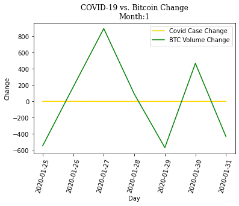

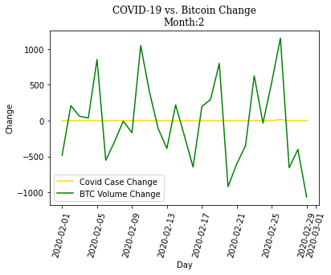

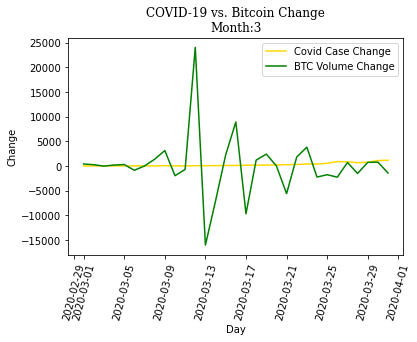

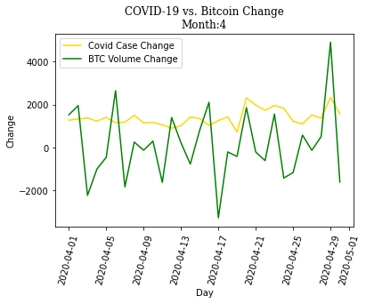

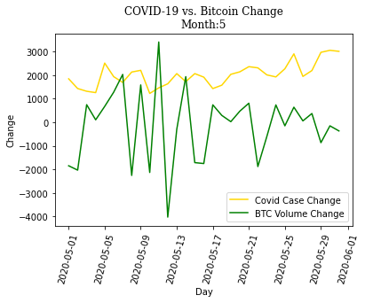

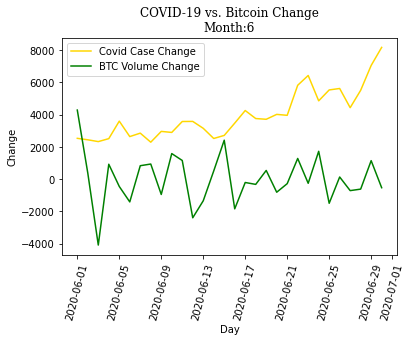

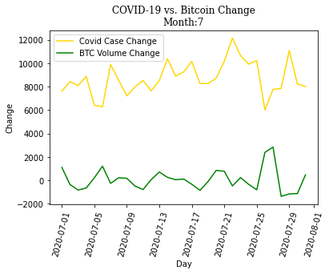

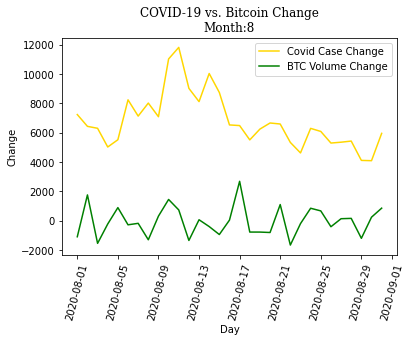

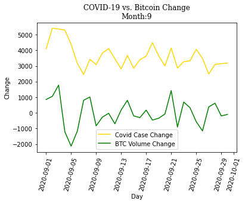

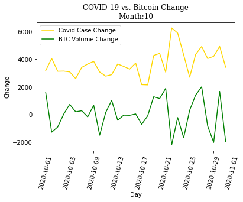

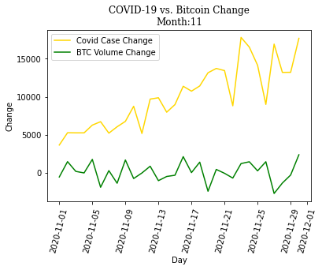

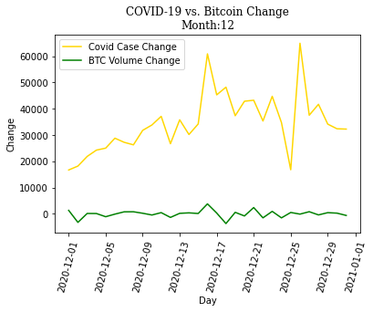

```python
# Lets look at Califonia data in closer detail, using each month instead
# of looking at all data at once

# To make things easier, lets combine the two dataframes into one, using
# date as the unique key to link both. Merge will only keep the values
# for which date is present in both ca and btc dataframes
btc.rename(columns={'change':'btc_change'}, inplace=True)
df = pd.merge(ca, btc, on='date')

# Creating seperate column to store day, month and year information
df['month'] = df['date'].dt.month
df['year'] = df['date'].dt.year
df['day'] = df['date'].dt.day

# Seperate 2020 data from 2021 data
groups = df.groupby('year')
# We'll store this in years
years = {}
for year, dataframe in groups:
    years[str(year)] = dataframe.copy()

# Focusing on 2020 data
twenty = years['2020'].copy()

# To make the analysis more focused, lets further group by month
groups = twenty.groupby('month')
months = [v for k, v in groups]

# Lets plot the data for each month
for i, m in enumerate(months):
    plt.plot(m['date'], m['change'], c='gold', label='Covid Case Change')
    plt.plot(m['date'], m['btc_change'], c='g', label='BTC Volume Change')
    plt.xticks(rotation=75, fontsize=10)
    plt.title('COVID-19 vs. Bitcoin Change\nMonth:{}'.format(i+1),
              fontdict={'fontname':'serif', 'fontsize':12})
    plt.xlabel('Day')
    plt.ylabel('Change')
    plt.legend()
    plt.show()
```

This closer look definitely provides a better visual insight into how changes for both, COVID Cases and BTC Volume in California may be similar. Looking at the graphs, there is a relation between change, especially for months 9, 10 and 11. However, the overall scale of change is different for both.

This approach can be further improved, and modified to obtain a statistically significant result, using Hypotheses Testing. However, in order to keep this tutorial fairly straightforward, we will not be discussing Hypothesis Testing. Check the resources section for additional reading information on this.

## Machine Learning (A Brief Insight)

Machine learning can always be 'fun' with it being all the rage right now. Given such a complex topic, it will be beyond the scope of this tutorial to go into details about how ML models work, and their implementation.

However, in order to give the reader some insight into how ML can easily be applied to model Linear Data, a demonstration is given to essentially 'predict' the number of covid cases.

The reader is highly encouraged to use this information only as a reference into ML, and look at the resources tab for resources containing much more indepth information into this powerful mathematical modelling tool.

We'll now briefly dive into fitting a linear relationship between BTC volume traded, and COVID-19 data, in order to see if there is actually a linear relation between the two. s

```python
# Again, given our preliminary analysis, as well as to keep things simple,
# we will be focusing on California

# Lets create the model

# We will use the OLS Regression model, as given by the statsmodels api.
# OLS or ordinary least squares is generally favored for fitting fairly
# linear data.

# Import statsmodels library
import statsmodels.api as sm

# Get the 'training' data, convert to numpy array and resize
X = np.array(df['change']).reshape(-1, 1)
y = np.array(df['btc_change']).reshape(-1, 1)

# Train the Linear Regression Model
model = sm.OLS(X, y).fit()

# Print the sumary for the Model
print(model.summary())
```

```
                                 OLS Regression Results
=======================================================================================
Dep. Variable:                      y   R-squared (uncentered):                   0.000
Model:                            OLS   Adj. R-squared (uncentered):             -0.002
Method:                 Least Squares   F-statistic:                            0.02466
Date:                Sun, 16 May 2021   Prob (F-statistic):                       0.875
Time:                        12:03:38   Log-Likelihood:                         -5210.5
No. Observations:                 476   AIC:                                  1.042e+04
Df Residuals:                     475   BIC:                                  1.043e+04
Df Model:                           1
Covariance Type:            nonrobust
==============================================================================
                 coef    std err          t      P>|t|      [0.025      0.975]
------------------------------------------------------------------------------
x1             0.0476      0.303      0.157      0.875      -0.548       0.643
==============================================================================
Omnibus:                      240.739   Durbin-Watson:                   0.082
Prob(Omnibus):                  0.000   Jarque-Bera (JB):             1002.395
Skew:                           2.370   Prob(JB):                    2.15e-218
Kurtosis:                       8.298   Cond. No.                         1.00
==============================================================================

Notes:
[1] R² is computed without centering (uncentered) since the model does not contain a constant.
[2] Standard Errors assume that the covariance matrix of the errors is correctly specified.
```

Looking at the model summary, it is clear that a Linear Model fit is clearly not the way to go. This does give intuition as to how one might go about trying to 'fit' data and create predictions based off of historical values.

Lets still plot the results to see what we have here.

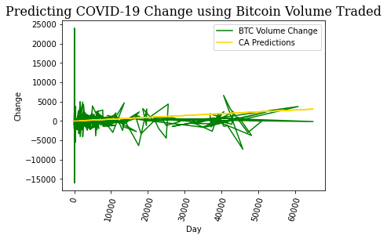

```python
# Get the model residuals, and predictions, store in a new column in the
# dataframe
df['residuals'] = model.resid
df['predictions'] = model.predict(X)

# Lets plot the prediction results
plt.plot(df['change'], df['btc_change'], c='g', label='BTC Volume Change')
plt.plot(df['change'], df['predictions'], c='gold', label='CA Predictions')
plt.xticks(rotation=75, fontsize=10)
plt.title('Predicting COVID-19 Change using Bitcoin Volume Traded',
          fontdict={'fontname':'serif', 'fontsize':16})
# Add labels to increase readability
plt.xlabel('Day')
plt.ylabel('Change')
plt.legend()
# Show the plot
plt.show()
```

While this approach did not work out, it does give insight into what goes into conducting such an analysis, and paves the way for future findings using some more robust methods.

Lets plot the residuals, just to get an intuition into what they look like.

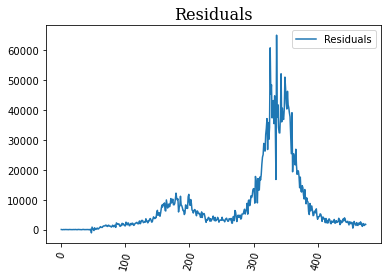

```python
# Lets plot the residuals
plt.plot(df['residuals'], label='Residuals')
plt.xticks(rotation=75, fontsize=10)
plt.title('Residuals', fontdict={'fontname':'serif', 'fontsize':16})
# Add labels to increase readability
plt.legend()
# Show the plot
plt.show()
```

The residuals represent the differnce between the predicted and calculated values. For such a regression, based of the graph of predictions, and the one above for residuals, it further certains the fact that a Linear approach is not valid here. However, it is still interesting to look at the shape, and see how the distribution of residuals is fairly normal in segments.

This may point towards another approach, where the data is looked at with an even closer lens, for a specified timeline.

# Findings

Through our mini data analysis pipeline, we have been able to walk through the process of gathering and tidying data, conducting exploratory analysis, create interactive visualizations, and take a deep dive into finding a relation between two different variables.

In the exploratory analysis, we saw through visualizations the covid cases for different states in the US, with their recovery and deaths. We then mapped this data using Folium onto an interactive map, which can be further improved to create a covid dashboard.

We then stepped into a more deeper analysis, looking into covid data over time, and its correlation, if any, with bitcoin change volume. Through more data wrangling, we were able to visualize BITCOIN volume change and COVID case change for California over the 12 months of 2020.

As stated before, the goal of this tutorial was not to prove something, but rather **communicate** the results, and approach throughout the pipeline. All of the code used has been commented, with detailed text explanations given at the relevant steps, to communicate the reasoning behind each step. This tutorial hopes that the reader was able to learn atleast somethings out of this, and gain enough excitement about Data Science, to hopefully pursue it further, on their own.

# Next Steps

This data analysis is not thorough in any regard. It has specifically been left as an open ended project, to encourage the readers to 'fork' this repository, and continue this project further, and come up with some interesting findings. In relation to what we have done in the tutorial, some ideas for future analysis are -

1. Segmenting data and looking at a specific time range for BTC vs. Covid As pointed out before, it may be more helpful to use a linear relationship to fit the data in a specific time segment. This could be a particular month for example, where the plots are fairly linear, giving intuition towards a linear model which may fit well.
2. Data Normalization Currently, we only look at the change between the values in order to draw correlation and look at the distribution. However, this is a case where normalization may come in handy, in order to 'equalize' things better.
3. Using more variables to fit the model and Hypotheses Testing Current approach only use the change as a way to model a linear relation. However, introducing more variables, and then running a model to try and fit the data may give more robust results. In addition, Hypotheses Testing should be done to provide a statistical backing to the analysis, over just saying that the model 'looks linear enough'.
4. Using the Mask dataset The tutorial includes the set up for a dataset which contains data about the population's likeliness to wear a mask, given by county. This is valuable data, presented in a continous form, which can be used to validate if wearing face masks does actually account for a decrease in the number of covid cases for a particular county. A FIPS mapping has already been done in the Tidying Data section, to make the correlation between state data and mask data easy.
5. Taking into account other factors Apart from volume change, other factors should be looked at, to see if there are some interesting correlations. These included, again conducting hypothesis testing, and looking at more specific factors, such aseconomic factors, policy changes, restrictions and regualtion implementations.

# Resources

## Python Resources

- [Folium](http://python-visualization.github.io/folium/)
- [Matplotlib](https://matplotlib.org/)
- [Numpy](https://numpy.org/)
- [Pandas](https://pandas.pydata.org/)
- [StatsModel](https://www.statsmodels.org/stable/index.html)

## Finding Data

- [Kaggle](https://www.kaggle.com/datasets)
- [Data.World](https://data.world/)
- [Data.gov](https://www.data.gov/)
- [Crypto Data](https://www.cryptodatadownload.com/)

## Data Science

- [CMSC320: Introduction to Data Science](https://cmsc320.github.io/)

### Hypotheses Testing

- [Great article in Towards DataScience](https://towardsdatascience.com/everything-you-need-to-know-about-hypothesis-testing-part-i-4de9abebbc8a#:~:text=Using%20Hypothesis%20Testing%2C%20we%20try,supported%20by%20the%20sample%20data.)
- [Machine Learning Mastery](https://machinelearningmastery.com/statistical-hypothesis-tests/)
- [Hypothesis Testing](https://www.statisticshowto.com/probability-and-statistics/hypothesis-testing/)

### Machine Learning

- [ML Crash Course](https://google-developers.appspot.com/machine-learning/crash-course/ml-intro)
- [Curated List of ML Articles](https://towardsdatascience.com/machine-learning/home)

### Miscellaneous

- [NY Times Article on Map Viz](https://www.nytimes.com/interactive/2020/07/17/upshot/coronavirus-face-mask-map.html)